# Lab 04 Ridge, Lasso, Elastic Net

Andy Jiang

2020-03-05

### Load packages

```r
library(tidyverse)
library(tidymodels)
```

### Exercise 1

```r
music<- read.csv("music.csv",header = TRUE)

set.seed(7)

music_split <- initial_split(music, prop=0.5)
music_split
```

```
## <250/250/500>
```

```r
music_test <- testing(music_split)

music_train <- training(music_split)
```

As we can see, there are 73 variables in both the training and the testing dataset. Both have 250 observations each.

### Exercise 2

```r
lm_spec <-
  linear_reg()%>%
  set_engine(engine = "lm")
lm_spec
```

```
## Linear Regression Model Specification (regression)
##
## Computational engine: lm
```

```r
ols_train <- fit(lm_spec,
                 lat~.,
                 data = music_train)

ols_train
```

```
## parsnip model object
##
## Fit time:  10ms
##
## Call:
## stats::lm(formula = formula, data = data)
##
## Coefficients:
## (Intercept)           X1           X2           X3           X4           X5
##    26.96078      7.77733     -4.67974      0.02363     -3.45902     -3.39247
##          X6           X7           X8           X9          X10          X11
##    -5.39093     -0.24389      0.04468     -2.12189      1.85842      0.51900
##         X12          X13          X14          X15          X16          X17
##    -1.42275      1.88077      0.59823      0.19180     -3.87833      0.05831
##         X18          X30          X31          X32          X33          X34
##     1.84570    -19.59828     20.26683     -5.05696      0.71284      1.33751
##         X35          X36          X37          X38          X39          X40
##     0.91529      4.02214      0.18878     -6.23256     -0.04814      1.47253
##         X41          X42          X43          X44          X45          X46
##    -6.65173     -1.94198     -2.63433      3.40707      5.16063      3.09955
##         X47          X59          X60          X61          X62          X63
##    -2.85777    -11.38594      8.03965      1.87308      0.39485     -5.37748
##         X64          X65          X66          X67          X68          X69
##    -0.93703      0.20679      4.31691     -1.14801     -0.22368     -1.93959
##         X70          X71          X72          X73          X74          X75
##    -2.23220      4.66003      2.02398      0.42867     -0.67525     -2.10647
##         X76          X88          X89          X90          X91          X92
##     2.77733     11.41551     -9.40011     -0.22590     -8.48190     -0.64783
##         X93          X94          X95          X96          X97          X98
##     2.52090     -2.70253     -6.04446      3.38595      3.05364     -1.52158
##         X99         X100         X101         X102         X103         X104
##     6.78400     -4.58508     -0.69940     -3.95502     -4.05255     -2.52969
##        X105
##    -0.51366
```

```r
lat_pred<-ols_train %>%
  predict(new_data = music_test)%>%
  bind_cols(music_test)
lat_pred %>%
  rmse(truth=lat,estimate=.pred)
```

```
## # A tibble: 1 x 3
##   .metric .estimator .estimate
##   <chr>   <chr>          <dbl>
## 1 rmse    standard        18.6
```

The testing root men squared error obtained is 18.616

### Exercise 3

$@$ for 3-5 how do i use the testing portion of the initially split data.

```r
set.seed(7)
music_cv <- vfold_cv(music_train, 10)
ridge_spec <- linear_reg(penalty = tune(), mixture = 0)%>%
  set_engine("glmnet")

rec <- recipe(lat ~., data = music_train)%>%
  step_scale(all_predictors())



grid<-expand_grid(penalty = seq(0,100, by =10))

tuning <- tune_grid(ridge_spec,
                    preprocessor = rec,
                    grid = grid,
                    resamples = music_cv)

tuning %>%
  collect_metrics()%>%
  filter(.metric== "rmse")%>%
  arrange(mean)
```

```
## # A tibble: 11 x 6
##    penalty .metric .estimator  mean     n std_err
##      <dbl> <chr>   <chr>      <dbl> <int>   <dbl>
##  1      10 rmse    standard    17.5    10   0.472
##  2      20 rmse    standard    17.6    10   0.475
##  3      30 rmse    standard    17.6    10   0.506
##  4      40 rmse    standard    17.7    10   0.536
##  5      50 rmse    standard    17.7    10   0.563
##  6      60 rmse    standard    17.7    10   0.585
##  7      70 rmse    standard    17.8    10   0.604
##  8      80 rmse    standard    17.8    10   0.621
##  9      90 rmse    standard    17.9    10   0.636
## 10     100 rmse    standard    17.9    10   0.649
## 11       0 rmse    standard    18.5    10   0.890
```

Based on the table above, we can see that when the penalty is between 10 -20, the rmse is the lowest. Thus, we will repeat the tuning process to choose a penalty between 10-20.

```r
grid = expand_grid(penalty = seq(10,20, by =1))
tuning <- tune_grid(ridge_spec,
                    preprocessor = rec,
                    grid = grid,
                    resamples = music_cv)

tuning%>%
  collect_metrics()%>%
  filter(.metric == "rmse")%>%
  arrange(mean)
```

```
## # A tibble: 11 x 6
##    penalty .metric .estimator  mean     n std_err
##      <dbl> <chr>   <chr>      <dbl> <int>   <dbl>
##  1      12 rmse    standard    17.5    10   0.466
##  2      13 rmse    standard    17.5    10   0.465
##  3      11 rmse    standard    17.5    10   0.468
##  4      14 rmse    standard    17.5    10   0.465
##  5      10 rmse    standard    17.5    10   0.472
##  6      15 rmse    standard    17.5    10   0.465
##  7      16 rmse    standard    17.6    10   0.466
##  8      17 rmse    standard    17.6    10   0.468
##  9      18 rmse    standard    17.6    10   0.470
## 10      19 rmse    standard    17.6    10   0.472
## 11      20 rmse    standard    17.6    10   0.475
```

```r
ridge_spec <- linear_reg(penalty = 12, mixture = 0)%>%
  set_engine("glmnet")

ridge_fit <- fit(ridge_spec,
                 lat~.,
                 data = music_train)

ridge_pred <- ridge_fit %>%
  predict(new_data = music_test)%>%
  bind_cols(music_test)

ridge_pred %>%
  rmse(truth = lat, estimate = .pred)
```

```
## # A tibble: 1 x 3
##   .metric .estimator .estimate
##   <chr>   <chr>          <dbl>
## 1 rmse    standard        16.5
```

When $\lambda$ is 12, the test root mean squared error is the smallest. Thus, we choose $\lambda$ to be 12. The test RMSE is 16.467

###Exercise 4

```r
set.seed(7)

lasso_spec <- linear_reg(penalty = tune(), mixture = 1)%>%
  set_engine("glmnet")

grid <- expand_grid(penalty = seq(0,100, by = 1))

results <- tune_grid(lasso_spec,
                    rec,
                    grid = grid,
                    resamples = music_cv)
```

[output not shown]

[output not shown]

[output not shown]

[output not shown]

[output not shown]

[output not shown]

[output not shown]

[output not shown]

[output not shown]

[output not shown]

```r
results %>%
  collect_metrics()%>%
  filter(.metric == "rmse")%>%
  arrange(mean)
```

```
## # A tibble: 101 x 6
##    penalty .metric .estimator  mean     n std_err
##      <dbl> <chr>   <chr>      <dbl> <int>   <dbl>
##  1       1 rmse    standard    17.4    10   0.555
##  2       2 rmse    standard    17.7    10   0.652
##  3       3 rmse    standard    18.1    10   0.730
##  4       4 rmse    standard    18.5    10   0.809
##  5       5 rmse    standard    19.0    10   0.877
##  6       7 rmse    standard    19.1    10   0.881
##  7       8 rmse    standard    19.1    10   0.881
##  8       9 rmse    standard    19.1    10   0.881
##  9      10 rmse    standard    19.1    10   0.881
## 10      11 rmse    standard    19.1    10   0.881
## # … with 91 more rows
```

```r
lasso_spec <- linear_reg(penalty = 1, mixture = 1)%>%
  set_engine("glmnet")
lasso_fit <- fit(lasso_spec,
                 lat ~.,
                 data = music_train)
lasso_pred <- lasso_fit %>%
  predict(new_data = music_test)%>%
  bind_cols(music_test)

lasso_pred%>%
  rmse(truth=lat, estimate =.pred)
```

```
## # A tibble: 1 x 3
##   .metric .estimator .estimate
##   <chr>   <chr>          <dbl>
## 1 rmse    standard        16.5
```

It appears that when the penalty is 1, the test rmse is the lowest. The test rmse when the penalty is 1 is 16.513

###Exercise 5

```r
set.seed(7)
elasticNet_spec <- linear_reg(penalty = tune(), mixture = tune())%>%
  set_engine("glmnet")

grid <- expand_grid(penalty=seq(0,100, by = 10), mixture = seq(0,1,by = 0.1))

results <- tune_grid(elasticNet_spec,
                    rec,
                    grid = grid,
                    resamples = music_cv)
```

[output not shown]

[output not shown]

[output not shown]

[output not shown]

[output not shown]

[output not shown]

[output not shown]

[output not shown]

[output not shown]

[output not shown]

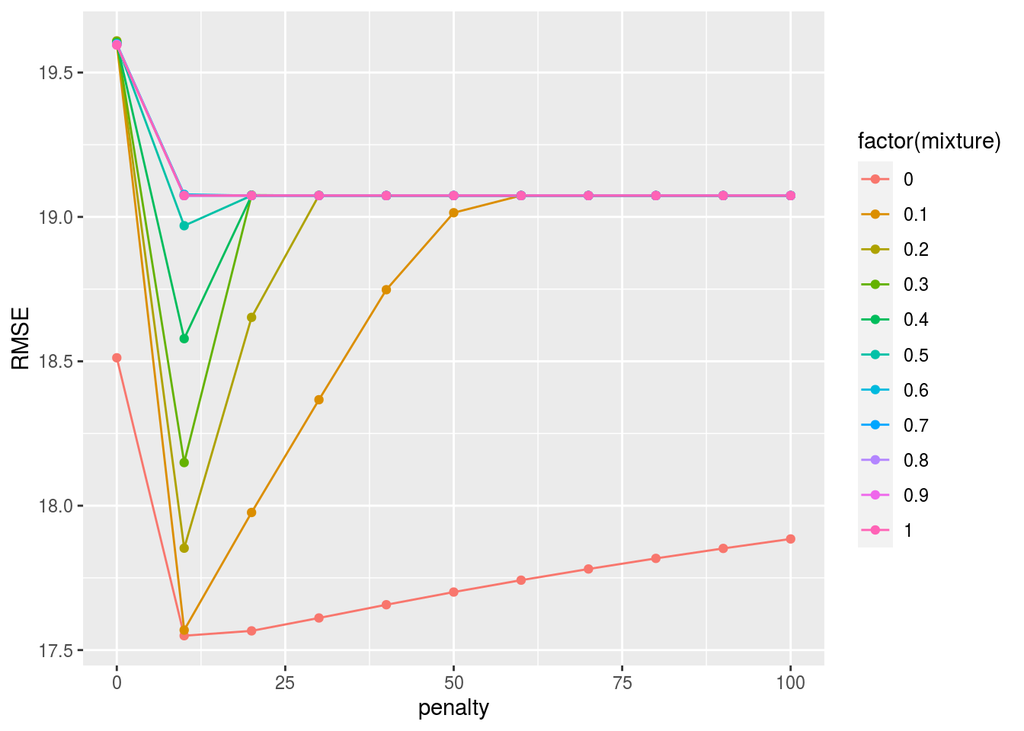

```r
results %>%
  collect_metrics()%>%
  filter(.metric == "rmse")%>%
  ggplot(aes(penalty, mean, color = factor(mixture), group = factor(mixture))) +
  geom_line() +
  geom_point()+
  labs(y = "RMSE")
```

```r
grid <- expand_grid(penalty=seq(0,20, by = 1), mixture = seq(0,1,by = 0.1))

results <- tune_grid(elasticNet_spec,
                     preprocessor = rec,
                     grid = grid,
                     resamples = music_cv)
```

[output not shown]

[output not shown]

[output not shown]

[output not shown]

[output not shown]

[output not shown]

[output not shown]

[output not shown]

[output not shown]

[output not shown]

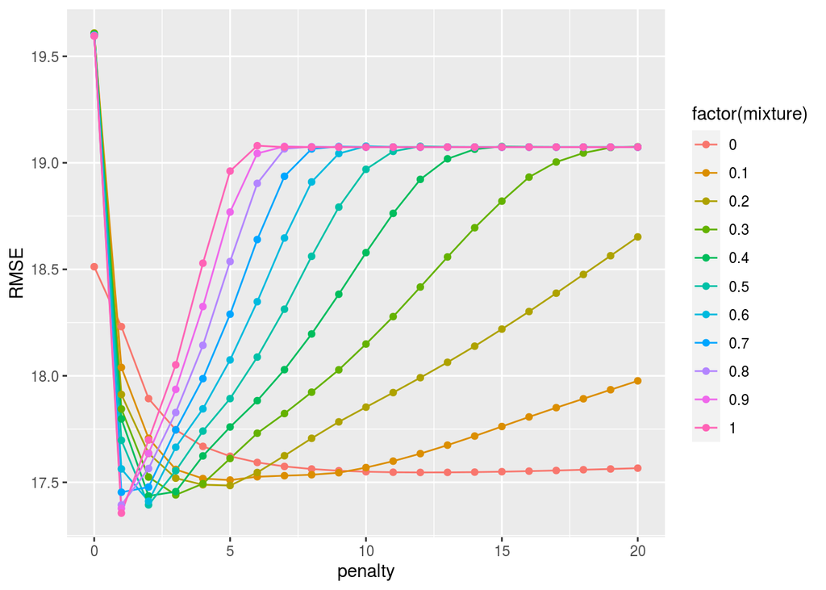

```r
results %>%
  collect_metrics()%>%
  filter(.metric == "rmse")%>%
  ggplot(aes(penalty, mean, color = factor(mixture), group = factor(mixture))) +
  geom_line() +
  geom_point()+
  labs(y = "RMSE")
```

As we can see from the graph, the lowest testing rmse occured when the penalty is below 5. Thus, we will restrict our search to $\lambda\in[0,5]$

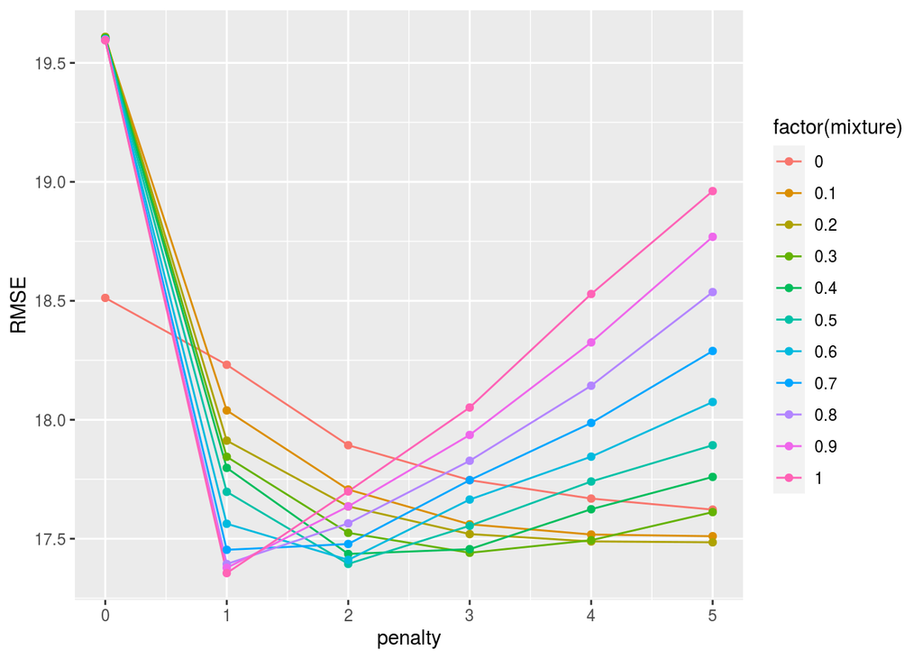

```r
grid <- expand_grid(penalty=seq(0,5, by = 1), mixture = seq(0,1,by = 0.1))

results <- tune_grid(elasticNet_spec,
                     preprocessor = rec,
                     grid = grid,
                     resamples = music_cv)



results %>%
  collect_metrics()%>%
  filter(.metric == "rmse")%>%
  ggplot(aes(penalty, mean, color = factor(mixture), group = factor(mixture))) +
  geom_line() +
  geom_point()+
  labs(y = "RMSE")
```

```r
results %>%
  collect_metrics()%>%
  filter(.metric == "rmse")%>%
  arrange(mean)
```

```
## # A tibble: 66 x 7
##    penalty mixture .metric .estimator  mean     n std_err
##      <dbl>   <dbl> <chr>   <chr>      <dbl> <int>   <dbl>
##  1       1     1   rmse    standard    17.4    10   0.555
##  2       1     0.9 rmse    standard    17.4    10   0.548
##  3       1     0.8 rmse    standard    17.4    10   0.553
##  4       2     0.5 rmse    standard    17.4    10   0.543
##  5       2     0.6 rmse    standard    17.4    10   0.565
##  6       2     0.4 rmse    standard    17.4    10   0.534
##  7       3     0.3 rmse    standard    17.4    10   0.527
##  8       1     0.7 rmse    standard    17.5    10   0.567
##  9       3     0.4 rmse    standard    17.5    10   0.561
## 10       2     0.7 rmse    standard    17.5    10   0.596
## # … with 56 more rows
```

```r
elasticNet_spec <- linear_reg(penalty = 1, mixture = 1)%>%
  set_engine("glmnet")

elasticNet_fit <- fit(elasticNet_spec,
                      lat~.,
                      data = music_train)

elasticNet_pred <- elasticNet_fit %>%
  predict(new_data = music_test)%>%
  bind_cols(music_test)

elasticNet_pred%>%
  rmse(truth = lat, estimate = .pred)
```

```
## # A tibble: 1 x 3
##   .metric .estimator .estimate
##   <chr>   <chr>          <dbl>
## 1 rmse    standard        16.5
```

By examing the table, we can see that when $\lambda$ is 1 and when $\alpha$ is 1, the elastic net yields the lowest test rmse of 16.513.

### Exercise 6

The test RMSE for linear regression is 18.62 The test RMSE for ridge is 16.467 The test RMSE for lasso is 16.513

In the previous exercise, our elastic net has a test rmse of 16.513. RMSE can be used to measure model fit. As the square root of a variance, RMSE illustrates the standard deviation of the unexplained variance. 16.513 is relatively low, thus, it shows that our model fit is relatively good. It means that the square root of the average of squared differences between our predicted latitude and the actual latitude is 16.513 degrees.